# Basic File I/O

36-350 – Statistical Computing

Week 5 – Fall 2020

# Formatted Text Files: Base R

If your data file is an ASCII (i.e., human-readable) text file . . .

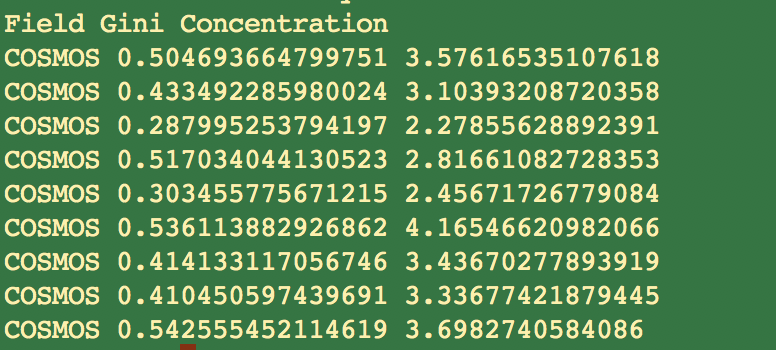

then you will generally use `read.table()` or `read.csv()`.

- `read.table()`: used with data whose values are separated by spaces.
- `read.csv()`: used when you have “comma-separated values”

Other alternatives include `read.delim()` and `scan()` (for more general formats), along with the heretofore often-used `readLines()` (which simply reads each line of a file into an element of a character vector).

We won’t go into binary (i.e., non-human-readable) files, as how to read in their data can be highly domain specific. To get a handle on how you might proceed if a binary reader has not already been coded for you, see the help page for `connections`.

# Formatted Text Files: Base R

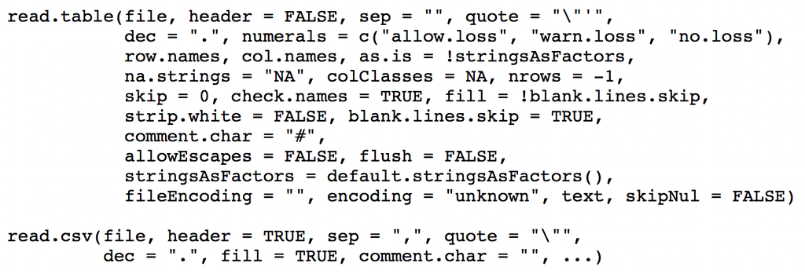

Beware the arguments!

- `header` provides column names, and is `FALSE` by default for `read.table()`
- `stringsAsFactors` is default `TRUE` and will lead to your character string vector being treated as a factor variable
- `na.strings` is `NA` by default, but beware: domain scientists use many symbols and/or numbers to indicate that data are missing (like -99)

Useful arguments:

- `skip`: if there are lines of metadata preceding the first line of data, use `skip` to skip over them.

Side effects:

- If your column name has white spaces, `read.table()` and `read.csv()` will fill them in with periods.

# Formatted Text Files: readr

Faster alternatives to base `R` functions are provided by the `readr` package, which as you might guess is part of the tidyverse.

- `read.table()` -> `read_table()` and `read.csv()` -> `read_csv()`
- **NOTE:** `read_table()` can do a bad job of parsing data; consider `read_delim()` instead
- keeps variable names as is
- columns of strings are read in as character vectors, but you can use the `col_types` argument to specify specific types, such as factor, to override the default identifications
- reads data into a tibble, which you may (or may not) want to cast to a data frame

```r
require(readr)
file.url = url("http://www.stat.cmu.edu/~pfreeman/GalaxyStatistics.txt") # see "connections"
read_delim(file.url,delim=" +") %>% head(3)
```

```
## # A tibble: 3 x 3
##   Field   Gini Concentration
##   <chr>  <dbl>         <dbl>
## 1 COSMOS 0.505          3.58
## 2 COSMOS 0.433          3.10
## 3 COSMOS 0.288          2.28
```

Click [here](https://rawgit.com/rstudio/cheatsheets/master/data-import.pdf) for more information than you could possibly ever need about `readr`.

# Reading Excel Files: readxl

`readxl` is yet another tidyverse-related package for reading data directly from EXCEL spreadsheets with either `xls` or `xlsx` extensions. (Note: does not yet, by all appearances, cleanly load non-local files!)

```r
require(readxl)
readxl_example()
```

```
##  [1] "clippy.xls"    "clippy.xlsx"   "datasets.xls"  "datasets.xlsx"
##  [5] "deaths.xls"    "deaths.xlsx"   "geometry.xls"  "geometry.xlsx"
##  [9] "type-me.xls"   "type-me.xlsx"
```

```r
(tbl = read_excel(readxl_example("clippy.xls")))
```

```
## # A tibble: 4 x 2
##   name                 value
##   <chr>                <chr>
## 1 Name                 Clippy
## 2 Species              paperclip
## 3 Approx date of death 39083
## 4 Weight in grams      0.90000000000000002
```

You can specify four column types: `skip`, `numeric`, `date`, and `text`.

`skip` allows you to ignore a column:

```r
(tbl = read_excel(readxl_example("clippy.xls"),col_types=c("text","skip"))) # ignore second column
```

```
## # A tibble: 4 x 1
##   name
##   <chr>
## 1 Name
## 2 Species
## 3 Approx date of death
## 4 Weight in grams
```

# Writing Files: Base R

As you might expect, `read.table()` and `read.csv()` have analogous write functions: `write.table()` and `write.csv()`. The two main arguments to look out for are:

- `quote`: default `TRUE`…it puts double quotes around your column (and row) names. Set this to `FALSE`.
- `row.names`: default `TRUE`…which means, if you don’t have row names in your data frame, you’ll have `"1"`, `"2"`, etc. as the row names in your output. Also set this to `FALSE` if you don’t have row names already.

# Writing Files: readr

Surprisingly, there is no `write_table()` function in `readr`; one can use `write_delim()` instead:

```r
write_delim(df,"./df.txt") # write the data frame df to the local file df.txt
```

By default, there are no quotes around the column names and no row names generated from the aether!

There is a `write_csv()` function for comma-separated values.

For EXCEL spreadsheets: use `write_excel_csv`.

# Storing R Objects: Save and Load

One can save `R` objects (vectors, data frames, etc.) in a binary format, so as to be loaded later:

```r
x = 5
y = list(a=1:2,b=TRUE)
save(x,y,file="tmp.Rdata")
rm(x,y)
gc()
```

```
##           used (Mb) gc trigger  (Mb) limit (Mb) max used (Mb)
## Ncells  987427 52.8    1974527 105.5         NA  1364448 72.9
## Vcells 1721481 13.2    8388608  64.0      16384  2510333 19.2
```

```r
load("tmp.Rdata")
x
```

```
## [1] 5
```

```r
y
```

```
## $a
## [1] 1 2
##
## $b
## [1] TRUE
```

Note the following:

- The suffixes `Rdata` and `Rda` are interchangable
- There is a `saveRDS()` function which saves *one* `R` object in a file with suffix `Rds`…this object may be given a new name when read in with `readRDS()`